# Biology as Data Science

Balan Ramesh

2/6/2019

# Biology as Data Science

- When you think of biology what comes to your mind?
- Let us expand the view with this [link](https://www.sciencedaily.com/releases/2015/05/150506120452.htm)
- The idea here is we consider genes, proteins and other molecules as data points and we try and gain insight into the “biology” of the organism.
- Why is this important? Why is this perspective of biology important?
  - It is important and valuable because we find the answer to biological question in the most fundamental way as possible.

# What is valuable to biology and why do we care?

- When I say valuable, I mean the true cause of an effect observed. For example, we know that males and females are fundamentally differently in their biology because of the Y chromosome in males.
  - Presence of Y chromosome, determines whether a zygote develops into a male or a female.
    - Now you could say that we can determine this using karyotyping.
    - I agree but we can not answer any further questions.
    - (i.e) Which gene or genes cause this effect of the development?
  - Now that is not possible to answer with karyotyping.
  - Thanks to data science, we now know that the presence of “SRY” gene in the Y chromosome is the true cause of the effect.
- Okay…..but whats in it for me?
  - Don’t you care about biology?
    - No…
  - Well, check the following links out.
    - [Link 1](https://www.indeed.com/jobs?q=Molecular+Biology&jt=fulltime)
    - [Link 2](https://www.indeed.com/q-microbiology-jobs.html)
    - [Link 3](https://www.indeed.com/jobs?q=Bioinformatics&l=)
  - So, do you care now?
    - If yes, you are in the right place.
    - I am super skeptical of your answer if it is no.

# If it is so valuable why do we not see many bioinformaticist or computational biologist?

- Welll….. Here is the catch.
  - It is relatively harder to be a bioinformaticist or computational biologist comparing traditional microbiolgist or molecular biologist.
- Okay…but why is it relatively harder though ?
  - Great question.
  - Here is your answer.

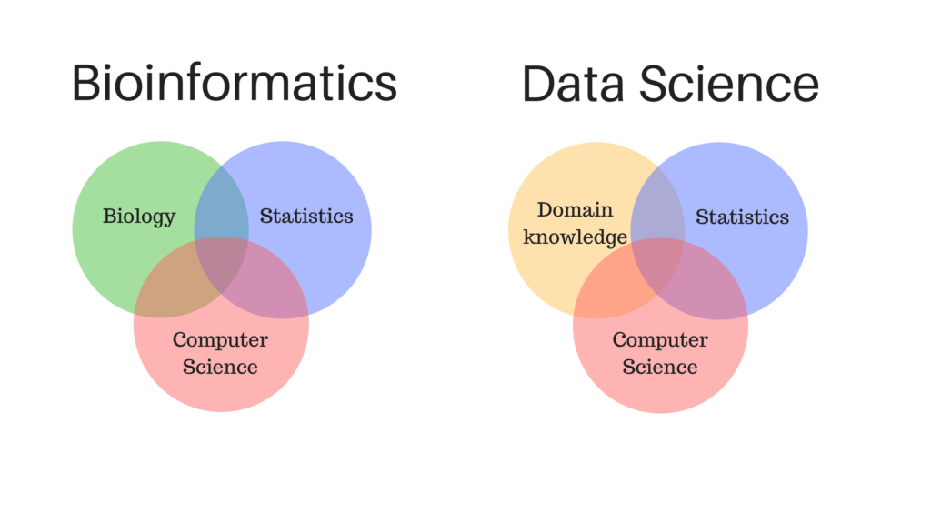

# So what do you think ?

**Are you ready for the challenge?**

[figure not shown]